# Supervied Learning Assignment

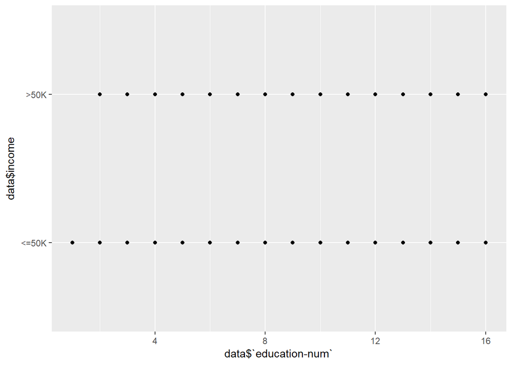

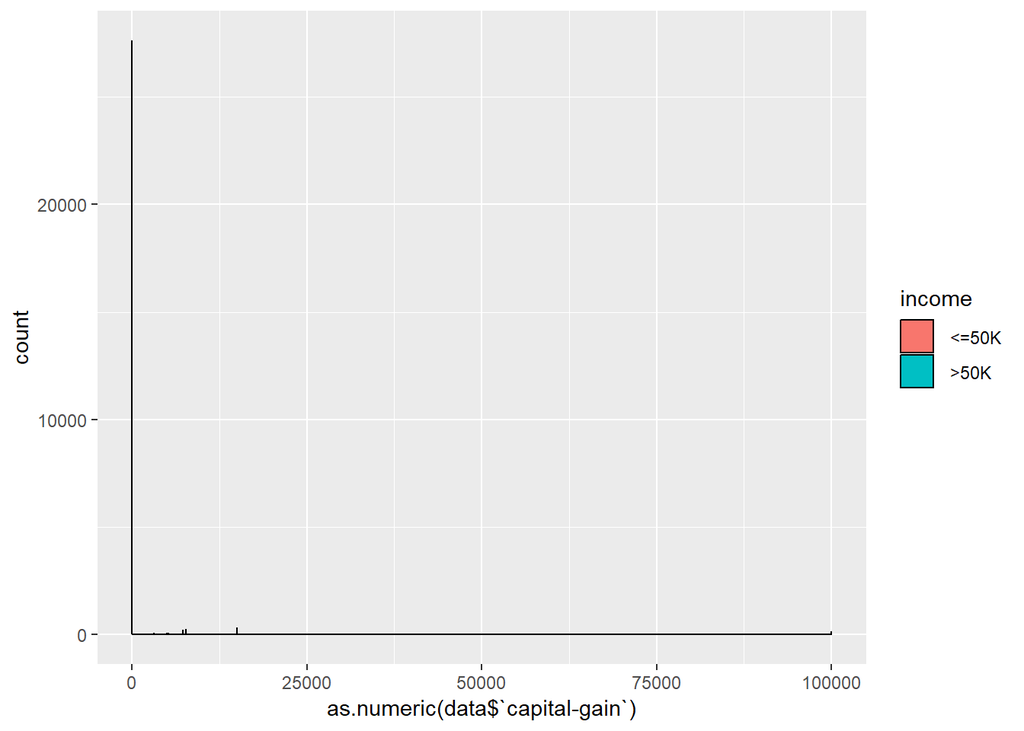

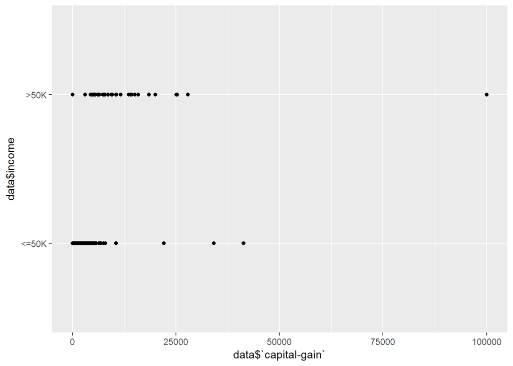

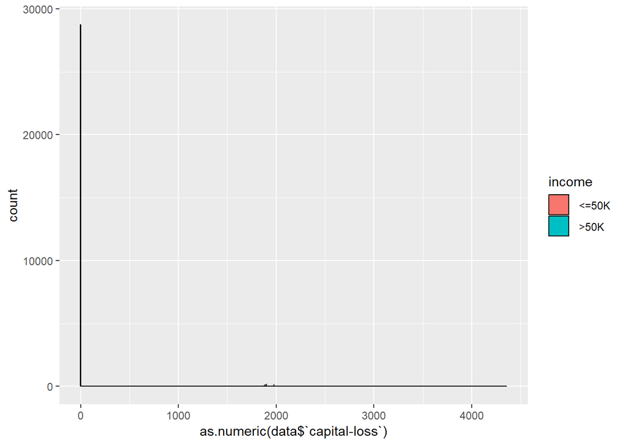

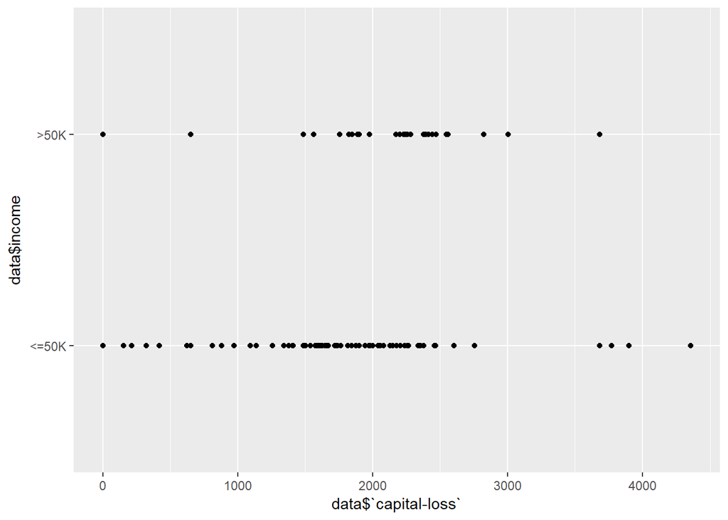

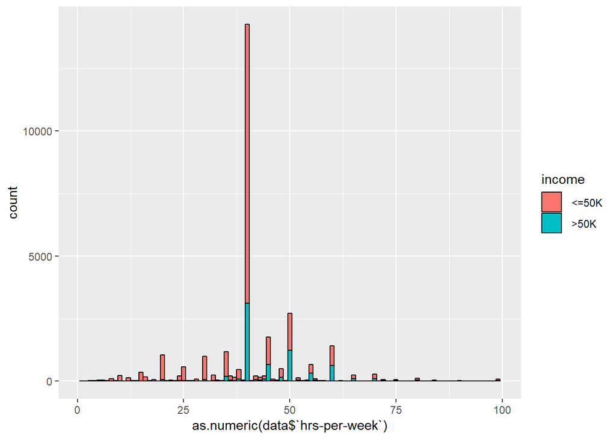

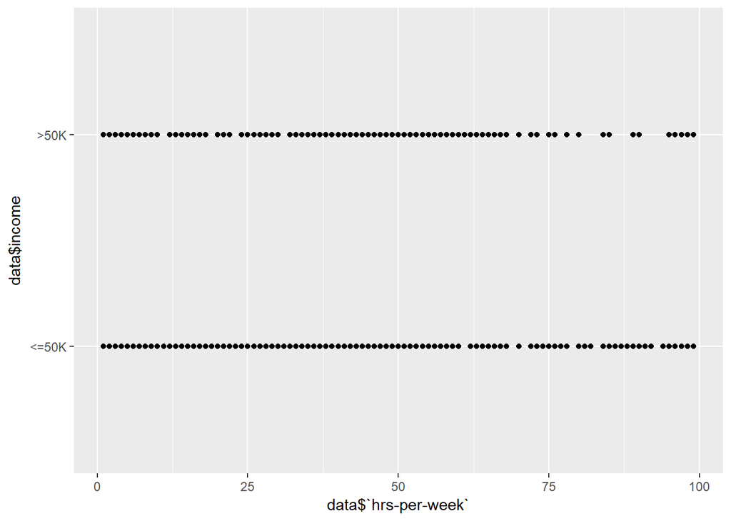

In all likeliness you are most likely to be valued less than 50K

Lets build models for this data set anyway and see which one is the best fit

```
## [1] 4262
```

```
## [1] 0.008726186
```

Lets redo importing the data set We are removing the variables with the biggest outliers that have no correlation with any factors We will keep duplicates and remove any rows with missing data All of the models we are using are supervised learning methods and are using k fold cross validation

For our first model lets use logic regression

```
##
##           <=50K  >50K
##    <=50K  20801  3039
##    >50K    1853  4469
```

It’s accuracy is 83% as the results show

Now lets try the C5 model

```
##
##           <=50K  >50K
##    <=50K  20981  2974
##    >50K    1673  4534
```

It’s accuracy comes out to 84%

Now lets try the logitBoost model

```
##
##           <=50K  >50K
##    <=50K  20844  3671
##    >50K    1810  3837
```

It’s accuracy comes out to 81%

Now lets try a svm model

```
##
##           <=50K  >50K
##    <=50K  21031  3603
##    >50K    1623  3905
```

It’s accuracy comes out to 83%

Now lets try Naive Bayes model

```
##
##           <=50K  >50K
##    <=50K  22647  7422
##    >50K       7    86
```

It’s accuracy comes out to only 75%

And for our last model lets do a neural net

```
##
##           <=50K  >50K
##    <=50K  20676  2986
##    >50K    1978  4522
```

it’s accuracy comes to 83%

With all those models the best one was the C5 model by only a slim margin Lets see how this model works

```
##
## Call:
## (function (x, y, trials = 1, rules = FALSE, weights = NULL, control
##  0, 0, 0, 0, 0, 0, 0, 0, 0, 0, 0, 0, 0, 0, 0, 0, 0, 0, 0, 0, 0, 0, 0,
##  0, 0, 0, 0, 0, 0, 0, 0, 0, 0, 0, 0, 0, 1, 0, 0, 0, 0,
##
##
## C5.0 [Release 2.07 GPL Edition]      Mon Feb 18 16:30:36 2019
## -------------------------------
##
## Class specified by attribute `outcome'
##
## Read 30162 cases (57 attributes) from undefined.data
##
## -----  Trial 0:  -----
##
## Decision tree:
##
## marStat Married-civ-spouse <= 0:
## :...education Doctorate > 0:
## :   :...age <= 32: <=50K (23/4)
## :   :   age > 32: >50K (94/34)
## :   education Doctorate <= 0:
## :   :...education Prof-school > 0:
## :       :...age <= 32: <=50K (51/9)
## :       :   age > 32: >50K (105/39)
## :       education Prof-school <= 0:
## :       :...education Masters <= 0: <=50K (15139/790)
## :           education Masters > 0:
## :           :...occupation Exec-managerial <= 0: <=50K (523/102)
## :               occupation Exec-managerial > 0:
## :               :...age <= 30: <=50K (20)
## :                   age > 30:
## :                   :...hrs.per.week <= 39: <=50K (14)
## :                       hrs.per.week > 39: >50K (128/50)
## marStat Married-civ-spouse > 0:
## :...education.num > 12:
##     :...occupation Other-service > 0: <=50K (54/18)
##     :   occupation Other-service <= 0:
##     :   :...occupation Farming-fishing > 0:
```

[output cut: 1775 more lines]

```
##   45.53% workclass Local-gov
##   44.95% race Asian-Pac-Islander
##   43.54% race White
##   42.40% occupation Sales
##   38.44% education HS-grad
##   37.09% education Assoc-voc
##   35.87% education 12th
##   34.38% education Assoc-acdm
##   27.17% education Some-college
##   11.39% workclass Private
##    8.50% marStat Married-spouse-absent
##    5.89% marStat Separated
##
##
## Time: 12.0 secs
```

In this model we can see the five attributes used the most were: age workclass education occupation marital status

```
   (a)   (b)    <-classified as
  ----  ----
 20981  1673    (a): class <=50K
  2973  4535    (b): class >50K
```

We see from the table that a majority of the time the model will classify someone as having a less income of $50000 but that's likely because of the biased data that it was trained with you can find the shiny app here. where you can test to see if you meet its requirements to have an income above 50,000$ the shiny app was exported to shiny.io by saving the model object in a file and read on the server side of the app https://www.shinyapps.io/admin/#/application/722712